# Google Data Analytics Capstone Project: Bellabeat

Josefina Perez Mercader

2023-06-12

### Case Study: How can a Wellness Technology Company play it smart?

## Introduction

Welcome to the Bellabeat data analysis case study! In this case study, you will perform many real-world tasks of a junior data analyst. You will imagine you are working for Bellabeat, a high-tech manufacturer of health-focused products for women, and meet different characters and team members. In order to answer the key business questions, you will follow the steps of the data analysis process: ask, prepare, process, analyze, share, and act. Along the way, the Case Study Roadmap tables — including guiding questions and key tasks — will help you stay on the right path.

By the end of this lesson, you will have a portfolio-ready case study. Download the packet and reference the details of this case study anytime. Then, when you begin your job hunt, your case study will be a tangible way to demonstrate your knowledge and skills to potential employers.

## Scenario

You are a junior data analyst working on the marketing analyst team at Bellabeat, a high-tech manufacturer of health-focused products for women. Bellabeat is a successful small company, but they have the potential to become a larger player in the global smart device market. Urška Sršen, co-founder and Chief Creative Officer of Bellabeat, believes that analyzing smart device fitness data could help unlock new growth opportunities for the company. You have been asked to focus on one of Bellabeat’s products and analyze smart device data to gain insight into how consumers are using their smart devices. The insights you discover will then help guide marketing strategy for the company. You will present your analysis to the Bellabeat executive team along with your high-level recommendations for Bellabeat’s marketing strategy.

## Characters and products

● Characters

○ Urška Sršen: Bellabeat’s co-founder and Chief Creative Officer

○ Sando Mur: Mathematician and Bellabeat’s co-founder; key member of the Bellabeat executive team

○ Bellabeat marketing analytics team: A team of data analysts responsible for collecting, analyzing, and reporting data that helps guide Bellabeat’s marketing strategy. You joined this team six months ago and have been busy learning about Bellabeat’’s mission and business goals — as well as how you, as a junior data analyst, can help Bellabeat achieve them.

● Products

○ Bellabeat app: The Bellabeat app provides users with health data related to their activity, sleep, stress, menstrual cycle, and mindfulness habits. This data can help users better understand their current habits and make healthy decisions. The Bellabeat app connects to their line of smart wellness products.

○ Leaf: Bellabeat’s classic wellness tracker can be worn as a bracelet, necklace, or clip. The Leaf tracker connects to the Bellabeat app to track activity, sleep, and stress.

○ Time: This wellness watch combines the timeless look of a classic timepiece with smart technology to track user activity, sleep, and stress. The Time watch connects to the Bellabeat app to provide you with insights into your daily wellness.

○ Spring: This is a water bottle that tracks daily water intake using smart technology to ensure that you are appropriately hydrated throughout the day. The Spring bottle connects to the Bellabeat app to track your hydration levels.

○ Bellabeat membership: Bellabeat also offers a subscription-based membership program for users. Membership gives users 24/7 access to fully personalized guidance on nutrition, activity, sleep, health and beauty, and mindfulness based on their lifestyle and goals.

## About the company

Urška Sršen and Sando Mur founded Bellabeat, a high-tech company that manufactures health-focused smart products. Sršen used her background as an artist to develop beautifully designed technology that informs and inspires women around the world. Collecting data on activity, sleep, stress, and reproductive health has allowed Bellabeat to empower women with knowledge about their own health and habits. Since it was founded in 2013, Bellabeat has grown rapidly and quickly positioned itself as a tech-driven wellness company for women.

By 2016, Bellabeat had opened offices around the world and launched multiple products. Bellabeat products became available through a growing number of online retailers in addition to their own e-commerce channel on their website. The company has invested in traditional advertising media, such as radio, out-of-home billboards, print, and television, but focuses on digital marketing extensively. Bellabeat invests year-round in Google Search, maintaining active Facebook and Instagram pages, and consistently engages consumers on Twitter. Additionally, Bellabeat runs video ads on YouTube and display ads on the Google Display Network to support campaigns around key marketing dates.

Sršen knows that an analysis of Bellabeat’s available consumer data would reveal more opportunities for growth. She has asked the marketing analytics team to focus on a Bellabeat product and analyze smart device usage data in order to gain insight into how people are already using their smart devices. Then, using this information, she would like high-level recommendations for how these trends can inform Bellabeat marketing strategy

## STEP 1: ASK

Business task: Analyze consumers use of an existing competitor to identify potential opportunities for growth and recommendations for the Bellabeat marketing strategy

Questions for the analysis: What are some trends in smart device usage? How could these trends apply to Bellabeat customers? How could these trends help influence Bellabeat’s marketing strategy? Key Stakeholders: · Urška Sršen — Bellabeat’s co-founder and Chief Creative Officer

· Sando Mur — Mathematician and Bellabeat’s co-founder; key member of the Bellabeat executive team

· Bellabeat marketing analytics team — A team of data analysts responsible for collecting, analyzing, and reporting data that helps guide Bellabeat’s marketing strategy.

## STEP 2: PREPARE

Limitations for this data exist due to the sample size and absence of key characteristics of the participants, such as gender, age, location, lifestyle.

For this analysis the data sets for daily activity, daily calories, daily intensities, daily steps, heart rate by seconds, minute METs, daily sleep, and weight log information, will be used.

Because of the largeness of the data sets being used, R Studio was used to prepare, process and complete this analysis of which the many packages and data visualization features available therein can be used to explore the data.

### Import the datasets:

The csv files were then imported into R Studio and the data frames were created with simplified names. In order to ensure the data frames were imported correctly the head() function was used. Then the tibble() function was used to take a look at the data and check if the data was in the correct format.

```r
install.packages("dplyr")
install.packages("tidyr")
install.packages("lubridate")
install.packages("readr")
library(dplyr)
library(tidyr)
library(lubridate)
library(readr)
dailyActivity_merged <- read_csv("dailyActivity_merged.csv")
dailyCalories_merged <- read_csv("dailyCalories_merged.csv")
dailyIntensities_merged <- read_csv("dailyIntensities_merged.csv")
dailySteps_merged <- read_csv("dailySteps_merged.csv")
minuteMETsNarrow_merged<- read_csv("minuteMETsNarrow_merged.csv")
heartrate_seconds_merged <- read_csv("heartrate_seconds_merged.csv")
sleepDay_merged <- read_csv("sleepDay_merged.csv")
weightLogInfo_merged <- read_csv("weightLogInfo_merged.csv")
head(dailyActivity_merged)
```

```
## # A tibble: 6 × 15
##           Id ActivityDate TotalSteps TotalDistance TrackerDistance
##        <dbl> <chr>             <dbl>         <dbl>           <dbl>
## 1 1503960366 4/12/2016         13162          8.5             8.5
## 2 1503960366 4/13/2016         10735          6.97            6.97
## 3 1503960366 4/14/2016         10460          6.74            6.74
## 4 1503960366 4/15/2016          9762          6.28            6.28
## 5 1503960366 4/16/2016         12669          8.16            8.16
## 6 1503960366 4/17/2016          9705          6.48            6.48
## # ℹ 10 more variables: LoggedActivitiesDistance <dbl>,
## #   VeryActiveDistance <dbl>, ModeratelyActiveDistance <dbl>,
## #   LightActiveDistance <dbl>, SedentaryActiveDistance <dbl>,
## #   VeryActiveMinutes <dbl>, FairlyActiveMinutes <dbl>,
## #   LightlyActiveMinutes <dbl>, SedentaryMinutes <dbl>, Calories <dbl>
```

```r
head(dailyCalories_merged)
```

```
## # A tibble: 6 × 3
##           Id ActivityDay Calories
##        <dbl> <chr>          <dbl>
## 1 1503960366 4/12/2016       1985
## 2 1503960366 4/13/2016       1797
## 3 1503960366 4/14/2016       1776
## 4 1503960366 4/15/2016       1745
## 5 1503960366 4/16/2016       1863
## 6 1503960366 4/17/2016       1728
```

```r
head(dailyIntensities_merged)
```

```
## # A tibble: 6 × 10
##         Id ActivityDay SedentaryMinutes LightlyActiveMinutes FairlyActiveMinutes
##      <dbl> <chr>                  <dbl>                <dbl>               <dbl>
## 1   1.50e9 4/12/2016                728                  328                  13
## 2   1.50e9 4/13/2016                776                  217                  19
## 3   1.50e9 4/14/2016               1218                  181                  11
## 4   1.50e9 4/15/2016                726                  209                  34
## 5   1.50e9 4/16/2016                773                  221                  10
## 6   1.50e9 4/17/2016                539                  164                  20
## # ℹ 5 more variables: VeryActiveMinutes <dbl>, SedentaryActiveDistance <dbl>,
## #   LightActiveDistance <dbl>, ModeratelyActiveDistance <dbl>,
## #   VeryActiveDistance <dbl>
```

```r
head(dailySteps_merged)
```

```
## # A tibble: 6 × 3
##           Id ActivityDay StepTotal
##        <dbl> <chr>           <dbl>
## 1 1503960366 4/12/2016       13162
## 2 1503960366 4/13/2016       10735
## 3 1503960366 4/14/2016       10460
## 4 1503960366 4/15/2016        9762
## 5 1503960366 4/16/2016       12669
## 6 1503960366 4/17/2016        9705
```

```r
head(minuteMETsNarrow_merged)
```

```
## # A tibble: 6 × 3
##           Id ActivityMinute         METs
##        <dbl> <chr>                 <dbl>
## 1 1503960366 4/12/2016 12:00:00 AM    10
## 2 1503960366 4/12/2016 12:01:00 AM    10
## 3 1503960366 4/12/2016 12:02:00 AM    10
## 4 1503960366 4/12/2016 12:03:00 AM    10
## 5 1503960366 4/12/2016 12:04:00 AM    10
## 6 1503960366 4/12/2016 12:05:00 AM    12
```

```r
head(heartrate_seconds_merged)
```

```
## # A tibble: 6 × 3
##           Id Time                 Value
##        <dbl> <chr>                <dbl>
## 1 2022484408 4/12/2016 7:21:00 AM    97
## 2 2022484408 4/12/2016 7:21:05 AM   102
## 3 2022484408 4/12/2016 7:21:10 AM   105
## 4 2022484408 4/12/2016 7:21:20 AM   103
## 5 2022484408 4/12/2016 7:21:25 AM   101
## 6 2022484408 4/12/2016 7:22:05 AM    95
```

```r
head(sleepDay_merged)
```

```
## # A tibble: 6 × 5
##           Id SleepDay        TotalSleepRecords TotalMinutesAsleep TotalTimeInBed
##        <dbl> <chr>                       <dbl>              <dbl>          <dbl>
## 1 1503960366 4/12/2016 12:0…                 1                327            346
## 2 1503960366 4/13/2016 12:0…                 2                384            407
## 3 1503960366 4/15/2016 12:0…                 1                412            442
## 4 1503960366 4/16/2016 12:0…                 2                340            367
## 5 1503960366 4/17/2016 12:0…                 1                700            712
## 6 1503960366 4/19/2016 12:0…                 1                304            320
```

```r
head(weightLogInfo_merged)
```

```
## # A tibble: 6 × 8
##           Id Date       WeightKg WeightPounds   Fat   BMI IsManualReport   LogId
##        <dbl> <chr>         <dbl>        <dbl> <dbl> <dbl> <lgl>            <dbl>
## 1 1503960366 5/2/2016 …     52.6         116.    22  22.6 TRUE           1.46e12
## 2 1503960366 5/3/2016 …     52.6         116.    NA  22.6 TRUE           1.46e12
## 3 1927972279 4/13/2016…    134.          294.    NA  47.5 FALSE          1.46e12
## 4 2873212765 4/21/2016…     56.7         125.    NA  21.5 TRUE           1.46e12
## 5 2873212765 5/12/2016…     57.3         126.    NA  21.7 TRUE           1.46e12
## 6 4319703577 4/17/2016…     72.4         160.    25  27.5 TRUE           1.46e12
```

```r
library(tibble)
tibble(dailyActivity_merged)
```

```
## # A tibble: 940 × 15
##            Id ActivityDate TotalSteps TotalDistance TrackerDistance
##         <dbl> <chr>             <dbl>         <dbl>           <dbl>
##  1 1503960366 4/12/2016         13162          8.5             8.5
##  2 1503960366 4/13/2016         10735          6.97            6.97
##  3 1503960366 4/14/2016         10460          6.74            6.74
##  4 1503960366 4/15/2016          9762          6.28            6.28
##  5 1503960366 4/16/2016         12669          8.16            8.16
##  6 1503960366 4/17/2016          9705          6.48            6.48
##  7 1503960366 4/18/2016         13019          8.59            8.59
##  8 1503960366 4/19/2016         15506          9.88            9.88
##  9 1503960366 4/20/2016         10544          6.68            6.68
## 10 1503960366 4/21/2016          9819          6.34            6.34
## # ℹ 930 more rows
## # ℹ 10 more variables: LoggedActivitiesDistance <dbl>,
## #   VeryActiveDistance <dbl>, ModeratelyActiveDistance <dbl>,
## #   LightActiveDistance <dbl>, SedentaryActiveDistance <dbl>,
## #   VeryActiveMinutes <dbl>, FairlyActiveMinutes <dbl>,
## #   LightlyActiveMinutes <dbl>, SedentaryMinutes <dbl>, Calories <dbl>
```

```r
tibble(dailyCalories_merged)
```

```
## # A tibble: 940 × 3
##            Id ActivityDay Calories
##         <dbl> <chr>          <dbl>
##  1 1503960366 4/12/2016       1985
##  2 1503960366 4/13/2016       1797
##  3 1503960366 4/14/2016       1776
##  4 1503960366 4/15/2016       1745
##  5 1503960366 4/16/2016       1863
##  6 1503960366 4/17/2016       1728
##  7 1503960366 4/18/2016       1921
##  8 1503960366 4/19/2016       2035
##  9 1503960366 4/20/2016       1786
## 10 1503960366 4/21/2016       1775
## # ℹ 930 more rows
```

```r
tibble(dailyIntensities_merged)
```

```
## # A tibble: 940 × 10
##         Id ActivityDay SedentaryMinutes LightlyActiveMinutes FairlyActiveMinutes
##      <dbl> <chr>                  <dbl>                <dbl>               <dbl>
##  1  1.50e9 4/12/2016                728                  328                  13
##  2  1.50e9 4/13/2016                776                  217                  19
##  3  1.50e9 4/14/2016               1218                  181                  11
##  4  1.50e9 4/15/2016                726                  209                  34
##  5  1.50e9 4/16/2016                773                  221                  10
##  6  1.50e9 4/17/2016                539                  164                  20
##  7  1.50e9 4/18/2016               1149                  233                  16
##  8  1.50e9 4/19/2016                775                  264                  31
##  9  1.50e9 4/20/2016                818                  205                  12
## 10  1.50e9 4/21/2016                838                  211                   8
## # ℹ 930 more rows
## # ℹ 5 more variables: VeryActiveMinutes <dbl>, SedentaryActiveDistance <dbl>,
## #   LightActiveDistance <dbl>, ModeratelyActiveDistance <dbl>,
## #   VeryActiveDistance <dbl>
```

```r
tibble(dailySteps_merged)
```

```
## # A tibble: 940 × 3
##            Id ActivityDay StepTotal
##         <dbl> <chr>           <dbl>
##  1 1503960366 4/12/2016       13162
##  2 1503960366 4/13/2016       10735
##  3 1503960366 4/14/2016       10460
##  4 1503960366 4/15/2016        9762
##  5 1503960366 4/16/2016       12669
##  6 1503960366 4/17/2016        9705
##  7 1503960366 4/18/2016       13019
##  8 1503960366 4/19/2016       15506
##  9 1503960366 4/20/2016       10544
## 10 1503960366 4/21/2016        9819
## # ℹ 930 more rows
```

```r
tibble(minuteMETsNarrow_merged)
```

```
## # A tibble: 1,325,580 × 3
##            Id ActivityMinute         METs
##         <dbl> <chr>                 <dbl>
##  1 1503960366 4/12/2016 12:00:00 AM    10
##  2 1503960366 4/12/2016 12:01:00 AM    10
##  3 1503960366 4/12/2016 12:02:00 AM    10
##  4 1503960366 4/12/2016 12:03:00 AM    10
##  5 1503960366 4/12/2016 12:04:00 AM    10
##  6 1503960366 4/12/2016 12:05:00 AM    12
##  7 1503960366 4/12/2016 12:06:00 AM    12
##  8 1503960366 4/12/2016 12:07:00 AM    12
##  9 1503960366 4/12/2016 12:08:00 AM    12
## 10 1503960366 4/12/2016 12:09:00 AM    12
## # ℹ 1,325,570 more rows
```

```r
tibble(heartrate_seconds_merged)
```

```
## # A tibble: 2,483,658 × 3
##            Id Time                 Value
##         <dbl> <chr>                <dbl>
##  1 2022484408 4/12/2016 7:21:00 AM    97
##  2 2022484408 4/12/2016 7:21:05 AM   102
##  3 2022484408 4/12/2016 7:21:10 AM   105
##  4 2022484408 4/12/2016 7:21:20 AM   103
##  5 2022484408 4/12/2016 7:21:25 AM   101
##  6 2022484408 4/12/2016 7:22:05 AM    95
##  7 2022484408 4/12/2016 7:22:10 AM    91
##  8 2022484408 4/12/2016 7:22:15 AM    93
##  9 2022484408 4/12/2016 7:22:20 AM    94
## 10 2022484408 4/12/2016 7:22:25 AM    93
## # ℹ 2,483,648 more rows
```

```r
tibble(sleepDay_merged)
```

```
## # A tibble: 413 × 5
##            Id SleepDay       TotalSleepRecords TotalMinutesAsleep TotalTimeInBed
##         <dbl> <chr>                      <dbl>              <dbl>          <dbl>
##  1 1503960366 4/12/2016 12:…                 1                327            346
##  2 1503960366 4/13/2016 12:…                 2                384            407
##  3 1503960366 4/15/2016 12:…                 1                412            442
##  4 1503960366 4/16/2016 12:…                 2                340            367
##  5 1503960366 4/17/2016 12:…                 1                700            712
##  6 1503960366 4/19/2016 12:…                 1                304            320
##  7 1503960366 4/20/2016 12:…                 1                360            377
##  8 1503960366 4/21/2016 12:…                 1                325            364
##  9 1503960366 4/23/2016 12:…                 1                361            384
## 10 1503960366 4/24/2016 12:…                 1                430            449
## # ℹ 403 more rows
```

```r
tibble(weightLogInfo_merged)
```

```
## # A tibble: 67 × 8
##            Id Date      WeightKg WeightPounds   Fat   BMI IsManualReport   LogId
##         <dbl> <chr>        <dbl>        <dbl> <dbl> <dbl> <lgl>            <dbl>
##  1 1503960366 5/2/2016…     52.6         116.    22  22.6 TRUE           1.46e12
##  2 1503960366 5/3/2016…     52.6         116.    NA  22.6 TRUE           1.46e12
##  3 1927972279 4/13/201…    134.          294.    NA  47.5 FALSE          1.46e12
##  4 2873212765 4/21/201…     56.7         125.    NA  21.5 TRUE           1.46e12
##  5 2873212765 5/12/201…     57.3         126.    NA  21.7 TRUE           1.46e12
##  6 4319703577 4/17/201…     72.4         160.    25  27.5 TRUE           1.46e12
##  7 4319703577 5/4/2016…     72.3         159.    NA  27.4 TRUE           1.46e12
##  8 4558609924 4/18/201…     69.7         154.    NA  27.2 TRUE           1.46e12
##  9 4558609924 4/25/201…     70.3         155.    NA  27.5 TRUE           1.46e12
## 10 4558609924 5/1/2016…     69.9         154.    NA  27.3 TRUE           1.46e12
## # ℹ 57 more rows
```

## STEP 3: PROCESS

By taking a look at the data it can be observed that the dailyActivity_merged data frame contains the information of the following data frames combined: dailyCalories_merged dailyIntensities_merged dailySteps_merged In order to avoid Redundancy in this analysis, we are only going to use the dailyActivity_merged data frame that contains all the information together.

dailyActivity_merged data frame is in chr format instead of Date format. The date format mdy was used to change it into the correct format:

```r
library(lubridate)
dailyActivity_merged$ActivityDate <- mdy(dailyActivity_merged$ActivityDate)
```

The same applies to the ActivityMinute in the minuteMETsNarrow_merged, the Time column in the heartrate_seconds_merged data frame, the Date column in the weightLogInfo_merged data frame and the SleepDay column in the sleepDay_merged data frame. But in this case the date format is different, it includes hour:minutes:seconds, so the date format used was mdy_hms:

```r
minuteMETsNarrow_merged$ActivityMinute <- mdy_hms(minuteMETsNarrow_merged$ActivityMinute)
heartrate_seconds_merged$Time <- mdy_hms(heartrate_seconds_merged$Time)
sleepDay_merged$SleepDay <- mdy_hms(sleepDay_merged$SleepDay)
weightLogInfo_merged$Date <- mdy_hms(weightLogInfo_merged$Date)
```

## STEP 4: ANALYZE

### Summarize the data:

The n_distinct() and nrow() functions are used to determine the number of unique values and the number of rows in a data frame, respectively.

```r
n_distinct(dailyIntensities_merged$Id)
```

```
## [1] 33
```

```r
nrow(dailyActivity_merged)
```

```
## [1] 940
```

```r
n_distinct(minuteMETsNarrow_merged$Id)
```

```
## [1] 33
```

```r
nrow(minuteMETsNarrow_merged)
```

```
## [1] 1325580
```

```r
n_distinct(heartrate_seconds_merged$Id)
```

```
## [1] 14
```

```r
nrow(heartrate_seconds_merged)
```

```
## [1] 2483658
```

```r
n_distinct(sleepDay_merged$Id)
```

```
## [1] 24
```

```r
nrow(sleepDay_merged)
```

```
## [1] 413
```

The summary() function is used to pull key statistics about the data frames.

```r
summary(dailyActivity_merged)
```

```
##        Id             ActivityDate          TotalSteps    TotalDistance
##  Min.   :1.504e+09   Min.   :2016-04-12   Min.   :    0   Min.   : 0.000
##  1st Qu.:2.320e+09   1st Qu.:2016-04-19   1st Qu.: 3790   1st Qu.: 2.620
##  Median :4.445e+09   Median :2016-04-26   Median : 7406   Median : 5.245
##  Mean   :4.855e+09   Mean   :2016-04-26   Mean   : 7638   Mean   : 5.490
##  3rd Qu.:6.962e+09   3rd Qu.:2016-05-04   3rd Qu.:10727   3rd Qu.: 7.713
##  Max.   :8.878e+09   Max.   :2016-05-12   Max.   :36019   Max.   :28.030
##  TrackerDistance  LoggedActivitiesDistance VeryActiveDistance
##  Min.   : 0.000   Min.   :0.0000           Min.   : 0.000
##  1st Qu.: 2.620   1st Qu.:0.0000           1st Qu.: 0.000
##  Median : 5.245   Median :0.0000           Median : 0.210
##  Mean   : 5.475   Mean   :0.1082           Mean   : 1.503
##  3rd Qu.: 7.710   3rd Qu.:0.0000           3rd Qu.: 2.053
##  Max.   :28.030   Max.   :4.9421           Max.   :21.920
##  ModeratelyActiveDistance LightActiveDistance SedentaryActiveDistance
##  Min.   :0.0000           Min.   : 0.000      Min.   :0.000000
##  1st Qu.:0.0000           1st Qu.: 1.945      1st Qu.:0.000000
##  Median :0.2400           Median : 3.365      Median :0.000000
##  Mean   :0.5675           Mean   : 3.341      Mean   :0.001606
##  3rd Qu.:0.8000           3rd Qu.: 4.782      3rd Qu.:0.000000
##  Max.   :6.4800           Max.   :10.710      Max.   :0.110000
##  VeryActiveMinutes FairlyActiveMinutes LightlyActiveMinutes SedentaryMinutes
##  Min.   :  0.00    Min.   :  0.00      Min.   :  0.0        Min.   :   0.0
##  1st Qu.:  0.00    1st Qu.:  0.00      1st Qu.:127.0        1st Qu.: 729.8
##  Median :  4.00    Median :  6.00      Median :199.0        Median :1057.5
##  Mean   : 21.16    Mean   : 13.56      Mean   :192.8        Mean   : 991.2
##  3rd Qu.: 32.00    3rd Qu.: 19.00      3rd Qu.:264.0        3rd Qu.:1229.5
##  Max.   :210.00    Max.   :143.00      Max.   :518.0        Max.   :1440.0
##     Calories
##  Min.   :   0
##  1st Qu.:1828
##  Median :2134
##  Mean   :2304
##  3rd Qu.:2793
##  Max.   :4900
```

```r
summary(minuteMETsNarrow_merged)
```

```
##        Id            ActivityMinute                        METs
##  Min.   :1.504e+09   Min.   :2016-04-12 00:00:00.00   Min.   :  0.00
##  1st Qu.:2.320e+09   1st Qu.:2016-04-19 01:51:00.00   1st Qu.: 10.00
##  Median :4.445e+09   Median :2016-04-26 06:27:00.00   Median : 10.00
##  Mean   :4.848e+09   Mean   :2016-04-26 12:09:55.15   Mean   : 14.69
##  3rd Qu.:6.962e+09   3rd Qu.:2016-05-03 18:55:00.00   3rd Qu.: 11.00
##  Max.   :8.878e+09   Max.   :2016-05-12 15:59:00.00   Max.   :157.00
```

```r
summary(heartrate_seconds_merged)
```

```
##        Id                 Time                            Value
##  Min.   :2.022e+09   Min.   :2016-04-12 00:00:00.00   Min.   : 36.00
##  1st Qu.:4.388e+09   1st Qu.:2016-04-19 06:18:10.00   1st Qu.: 63.00
##  Median :5.554e+09   Median :2016-04-26 20:28:50.00   Median : 73.00
##  Mean   :5.514e+09   Mean   :2016-04-26 19:43:52.24   Mean   : 77.33
##  3rd Qu.:6.962e+09   3rd Qu.:2016-05-04 08:00:20.00   3rd Qu.: 88.00
##  Max.   :8.878e+09   Max.   :2016-05-12 16:20:00.00   Max.   :203.00
```

```r
summary(sleepDay_merged)
```

```
##        Id               SleepDay                      TotalSleepRecords
##  Min.   :1.504e+09   Min.   :2016-04-12 00:00:00.00   Min.   :1.000
##  1st Qu.:3.977e+09   1st Qu.:2016-04-19 00:00:00.00   1st Qu.:1.000
##  Median :4.703e+09   Median :2016-04-27 00:00:00.00   Median :1.000
##  Mean   :5.001e+09   Mean   :2016-04-26 12:40:05.80   Mean   :1.119
##  3rd Qu.:6.962e+09   3rd Qu.:2016-05-04 00:00:00.00   3rd Qu.:1.000
##  Max.   :8.792e+09   Max.   :2016-05-12 00:00:00.00   Max.   :3.000
##  TotalMinutesAsleep TotalTimeInBed
##  Min.   : 58.0      Min.   : 61.0
##  1st Qu.:361.0      1st Qu.:403.0
##  Median :433.0      Median :463.0
##  Mean   :419.5      Mean   :458.6
##  3rd Qu.:490.0      3rd Qu.:526.0
##  Max.   :796.0      Max.   :961.0
```

```r
summary(weightLogInfo_merged)
```

```
##        Id                 Date                           WeightKg
##  Min.   :1.504e+09   Min.   :2016-04-12 06:47:11.00   Min.   : 52.60
##  1st Qu.:6.962e+09   1st Qu.:2016-04-19 15:19:45.00   1st Qu.: 61.40
##  Median :6.962e+09   Median :2016-04-27 23:59:59.00   Median : 62.50
##  Mean   :7.009e+09   Mean   :2016-04-27 15:39:54.27   Mean   : 72.04
##  3rd Qu.:8.878e+09   3rd Qu.:2016-05-04 15:24:10.50   3rd Qu.: 85.05
##  Max.   :8.878e+09   Max.   :2016-05-12 23:59:59.00   Max.   :133.50
##
##   WeightPounds        Fat             BMI        IsManualReport
##  Min.   :116.0   Min.   :22.00   Min.   :21.45   Mode :logical
##  1st Qu.:135.4   1st Qu.:22.75   1st Qu.:23.96   FALSE:26
##  Median :137.8   Median :23.50   Median :24.39   TRUE :41
##  Mean   :158.8   Mean   :23.50   Mean   :25.19
##  3rd Qu.:187.5   3rd Qu.:24.25   3rd Qu.:25.56
##  Max.   :294.3   Max.   :25.00   Max.   :47.54
##                  NA's   :65
##      LogId
##  Min.   :1.460e+12
##  1st Qu.:1.461e+12
##  Median :1.462e+12
##  Mean   :1.462e+12
##  3rd Qu.:1.462e+12
##  Max.   :1.463e+12
##
```

### Daily Activity Analysis

Total Steps: The average daily steps are 7638, which is below of 10,000, which is what the National Institutes of Health recommends to reduce your risk for cancer, heart disease and early death.

Very Active Minutes: On average, the users get 21.16 minutes of very activity per day, which means the users are getting 148.12 minutes of physical activity a week. This is bellow of what the CDC (Centers for Disease Control and Prevention) recommends, which is 150 minutes a week.

Sedentary Minutes: The CSEP (Canadian Society for Exercise Physiology) recommends not spending more then 8 ahours a day of sedentary time. If we take into account that the recommended amount of sleep is 8 hours (480 minutes) and the average of the users have a 991.20 minutes of sedentary time, we can assume that while awake, our users are 8.52 hours a day (991.2 minutes = 16.52 hours less than 8 hours sleep equals to 8.52 hours) which is slightly more of the that the CSEP recommends.

Calories The average FitBit user burns 2304 calories a day, which is more than the Clevelamd Clinic says a body should burn without physical activity. This means the users are somehow active during the course of the day.

### MET (Metabolic equivalents)

The average of the FitBit user has a metabolic equivalent of 14.69. According to the Harvard School of Public Healh, One MET is the amount of energy used while sitting quietly.For example, reading may use about 1.3 METs while running may use 8-9 METs. METs can also be translated into light, moderate, and vigorous intensities of exercise.

Sedentary—Uses 1.5 or fewer METs. Examples are sitting, reclining, or lying down. Light intensity—Uses from 1.6-3.0 METs. Examples are walking at a leisurely pace or standing in line at the store. Moderate intensity—Uses from 3.0-6.0 METs. Examples are walking briskly, vacuuming, or raking leaves. Vigorous intensity—Uses from 6.0+ METs. Examples are walking very quickly, running, taking an aerobics class, or shoveling snow.

An average on 14.69 MET is an unlikely value and this might lead to the conclusion that the data point is not calculated accurately. Due to this, this data frame will no longuer be used in the analysis.

### Daily Sleep

The summary of the Daily Sleep Data frame is telling us that the average user sleeps 419.5 minutes a day, which is the equivalent to 6.99 hours. This data is close to the CDC range which recommends that an adult should sleep more than 7 hours a day.

### BMI

BMI is a common tool that measures a person’s weight in relation to their height. The summary of the weight log info shows that the average user has a BMI of 25.19. According to Medical News, the ideal BMI is between 18.5 to 24.99. But this article also mentions that BMI is a very simple measurement. While it takes height into consideration, it does not account for factors such as: waist or hip measurements the proportion or distribution of fat the proportion of muscle mass So this data by itself does not diagnose how overweight a sample is.

### Create Reports

Based on the previous analysis, some reports were created to display critical information and evolution of the average data over time to identify some trends:

```r
dailyActivity_merged_v03 <- dailyActivity_merged %>%
  group_by(ActivityDate) %>%
  summarize(average_cal_user=((mean(Calories)/33)))
```

```r
dailyActivity_merged_v04 <- dailyActivity_merged %>%
  group_by(ActivityDate) %>%
  summarize(average_mins=mean(VeryActiveMinutes))
```

```r
dailyActivity_merged_v05 <- dailyActivity_merged %>%
  group_by(ActivityDate) %>%
  summarize(average_steps=mean(TotalSteps))
```

```r
dailySleepHours <- sleepDay_merged %>%
  group_by(SleepDay) %>%
  summarize(avg_hours=TotalMinutesAsleep/60)
daily_distance_calories <- dailyActivity_merged %>%
  group_by(ActivityDate, Id, Calories) %>%
  summarize(Distance=as.numeric (TotalDistance))
daily_distance_avg <- daily_distance_calories %>%
  group_by(ActivityDate) %>%
  summarize(avg_daily_distance=mean(Distance))
```

## STEP 5: SHARE

The ggplot() and gganimate() functions of R Studio were used to create data visualizations that depict patterns and trends found in the data frames, which can give us further insights for this project.

### First Plot: Relationship between Very Active Minutes and Calories burned

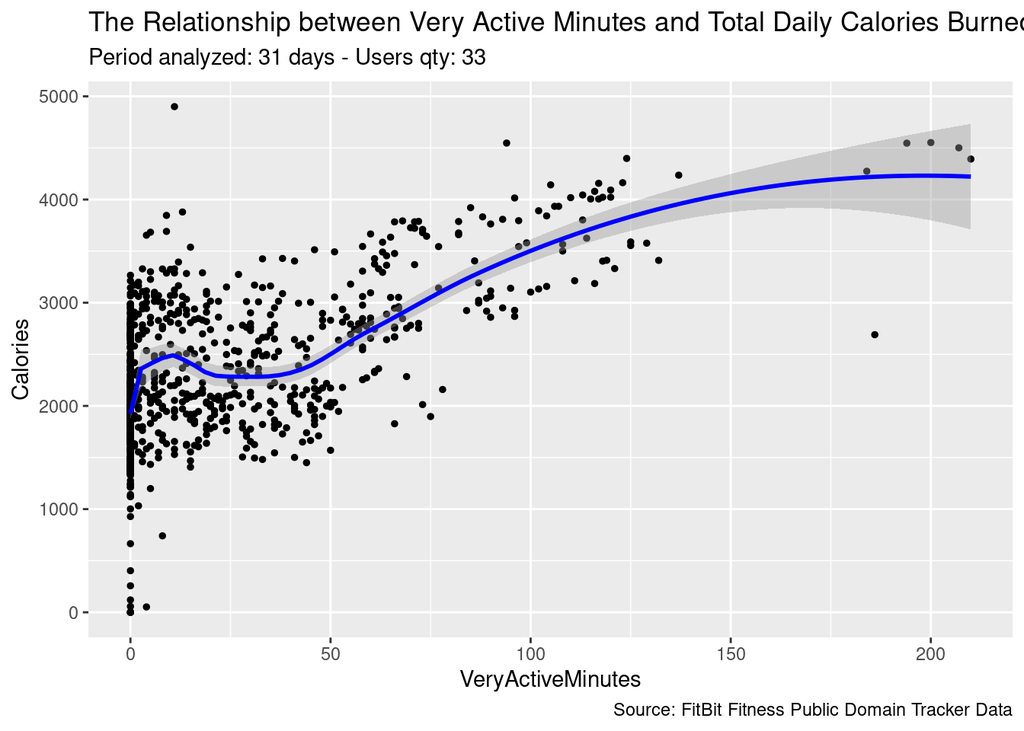

```r
install.packages("ggplot2")
library(ggplot2)
ggplot(dailyActivity_merged, aes(x=VeryActiveMinutes,y= Calories))+
  geom_point(size=1) +
  geom_smooth(span= 0.5, col='blue')+
  labs(title="The Relationship between Very Active Minutes and Total Daily Calories Burned",
       caption= "Source: FitBit Fitness Public Domain Tracker Data",
       subtitle = "Period analyzed: 31 days - Users qty: 33")
```

A positive Relationship between Very Active Minutes and Calories burned has been identified. The more active a user stays, the more calories they burn.

### Second Plot: Relationship between Total Steps and Calories burned

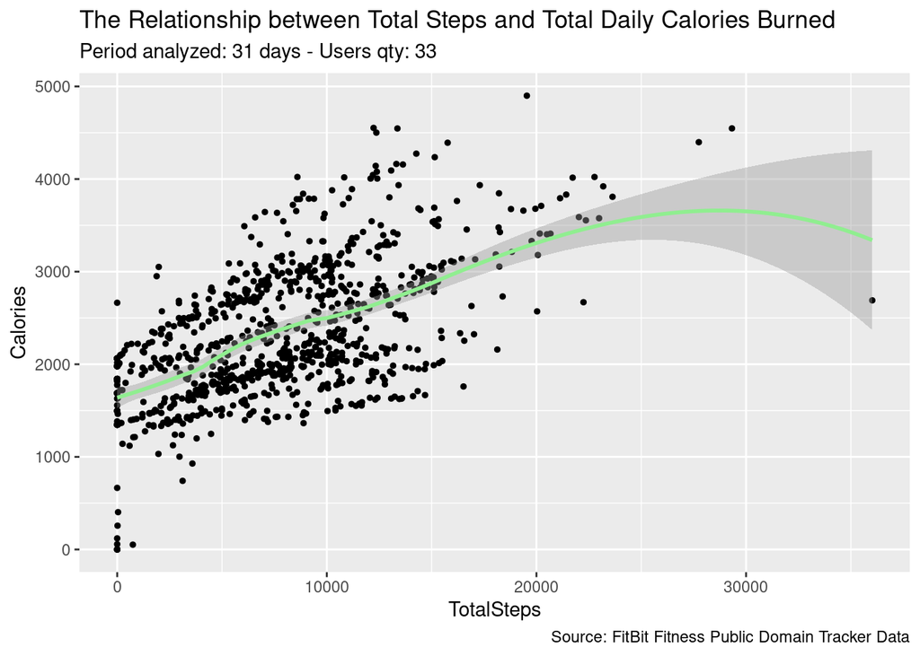

```r
ggplot(dailyActivity_merged, aes(x=TotalSteps,y= Calories))+
  geom_point(size=1) +
  geom_smooth(span=0.5, col='lightgreen') +
  labs(title="The Relationship between Total Steps and Total Daily Calories Burned",
       caption= "Source: FitBit Fitness Public Domain Tracker Data",
       subtitle = "Period analyzed: 31 days - Users qty: 33")
```

A positive Relationship between Total Steps and Calories burned has been identified. The more a user walks, the more calories they burn.

### Third Plot: Relationship between Distance and Calories burned

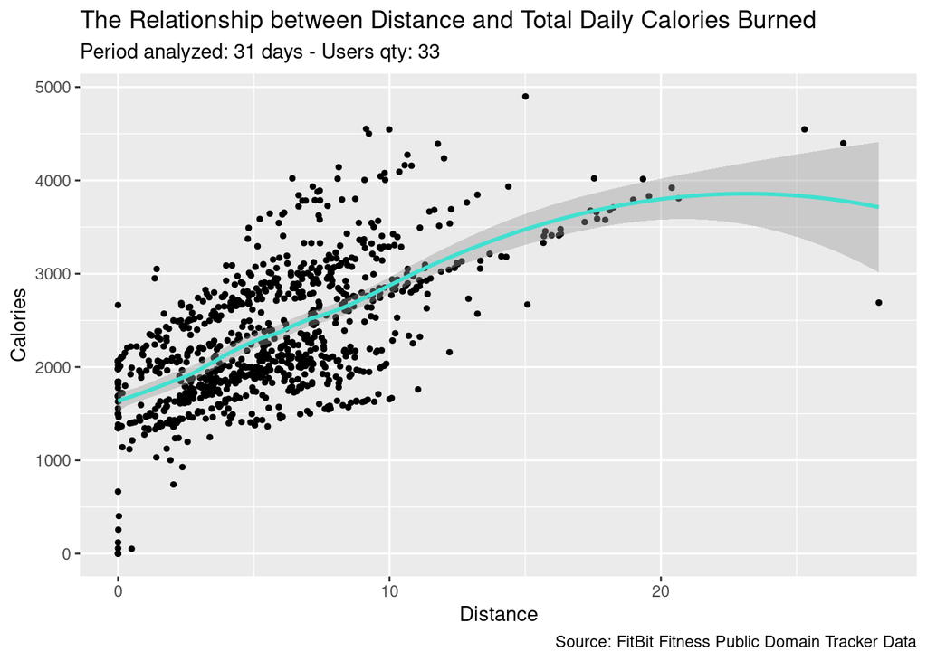

```r
ggplot(daily_distance_calories, aes(x=Distance,y= Calories))+
  geom_point(size=1) +
  geom_smooth(span=0.5, col='turquoise') +
  labs(title="The Relationship between Distance and Total Daily Calories Burned",
       caption= "Source: FitBit Fitness Public Domain Tracker Data",
       subtitle = "Period analyzed: 31 days - Users qty: 33")
```

A positive Relationship between Distance and Calories burned has been identified.

### Fourth Plot: Average Daily Calories burned Over Time

```r
##Create Plot
install.packages("gganimate")
install.packages("gifski")
library(gganimate)
library(gifski)
avg_daily_calories_by_user <- ggplot(dailyActivity_merged_v03, aes(x = ActivityDate, y = average_cal_user)) +
  geom_line(color="blue") +
  labs(title="The Average of Daily Calories burned by user Over Time",
       caption= "Source: FitBit Fitness Public Domain Tracker Data",
       subtitle = "Period analyzed: 31 days - Users qty: 33")
theme_light()
```

[output not shown]

[output cut: 376 more lines]

[output not shown]

```r
##Animate Plot
avg_daily_calories_by_user_animated <- avg_daily_calories_by_user +
  transition_reveal(ActivityDate)

animate(avg_daily_calories_by_user_animated)
```

```
## `geom_line()`: Each group consists of only one observation.
## ℹ Do you need to adjust the group aesthetic?
```

```
## `geom_line()`: Each group consists of only one observation.
## ℹ Do you need to adjust the group aesthetic?
```

```
## `geom_line()`: Each group consists of only one observation.
## ℹ Do you need to adjust the group aesthetic?
## `geom_line()`: Each group consists of only one observation.
## ℹ Do you need to adjust the group aesthetic?
```

[figure not shown]

```r
# Create the base plot
dailyCalories_by_user <- ggplot(dailyActivity_merged, aes(x = ActivityDate, y = Calories, color = as.factor(Id))) +
  geom_line() +
  theme_minimal()

# Animate the plot
dailyCalories_by_user_animated <- dailyCalories_by_user + transition_reveal(ActivityDate)

animate(dailyCalories_by_user_animated)
```

### Fifth Plot: Average Very Active Minutes Over Time

```r
##Create Plot
avg_daily_veryActiveMinutes <- ggplot(dailyActivity_merged_v04, aes(x = ActivityDate, y = average_mins)) +
  geom_line(color="blue") +
  labs(title="The Average of Very Active Minutes Over Time",
       caption= "Source: FitBit Fitness Public Domain Tracker Data",
       subtitle = "Period analyzed: 31 days - Users qty: 33")
theme_light()
```

[output not shown]

[output cut: 376 more lines]

[output not shown]

```
## `geom_line()`: Each group consists of only one observation.
## ℹ Do you need to adjust the group aesthetic?
## `geom_line()`: Each group consists of only one observation.
## ℹ Do you need to adjust the group aesthetic?
```

[figure not shown]

```r
##Animate Plot
avg_veryActiveMinutes_animated <- avg_daily_veryActiveMinutes +
  transition_reveal(ActivityDate)

animate(avg_veryActiveMinutes_animated)
```

### Sixth Plot: Average Steps Over Time

```r
avg_daily_steps <- ggplot(dailyActivity_merged_v05, aes(x = ActivityDate, y = average_steps)) +
  geom_line(color="blue") +
  labs(title="The Average Steps Over Time",
       caption= "Source: FitBit Fitness Public Domain Tracker Data",
       subtitle = "Period analyzed: 31 days - Users qty: 33")
theme_light()
```

[output not shown]

[output cut: 376 more lines]

[output not shown]

```
## `geom_line()`: Each group consists of only one observation.
## ℹ Do you need to adjust the group aesthetic?
## `geom_line()`: Each group consists of only one observation.
## ℹ Do you need to adjust the group aesthetic?
```

[figure not shown]

```r
##Animate Plot
avg_steps_animated <- avg_daily_steps +
  transition_reveal(ActivityDate)

animate(avg_steps_animated)
```

```r
avg_daily_sleepHours <- ggplot(dailySleepHours, aes(x = SleepDay, y = avg_hours)) +
  geom_line(color="blue") +
  labs(title="The Average Daily Sleep hours Over Time",
       caption= "Source: FitBit Fitness Public Domain Tracker Data",
       subtitle = "Period analyzed: 31 days - Users qty: 33")
theme_light()
```

[output not shown]

[output cut: 376 more lines]

[output not shown]

```
## `geom_line()`: Each group consists of only one observation.
## ℹ Do you need to adjust the group aesthetic?
## `geom_line()`: Each group consists of only one observation.
## ℹ Do you need to adjust the group aesthetic?
```

[figure not shown]

```r
##Animate Plot
avg_daily_sleepHours_animated <- avg_daily_sleepHours +
  transition_reveal(SleepDay)

animate(avg_daily_sleepHours_animated)
```

## STEP 6: ACT

As a final step, several recommendations were written to BellaBeat stakeholders.

### Recommendations for Bellabeat:

1. Target sedentary individuals by including reminders to move, personalized activity goals and set up challenges to enhance average daily physical activity.
2. Emphasize and educate about the importance of physical activity: including blogs and newsletters based on scientific information about the importance of having an active life to live longer and a better life.
3. Promote Sleep healthy habits: include in the newsletters and blogs articles about the importance of sleeping to minimizing the risks of having physical and mental illness. Promote healthy habits before sleeping via reminders and personalized sleep tips.
4. Enhance Heart Rate Monitoring: The average heart rate falls within the normal range, indicating that users have generally healthy heart rates. BellaBeat can further develop their heart rate monitoring features to provide more detailed insights into users’ cardiovascular health. This can include tracking resting heart rate trends, providing heart rate zone guidance during workouts, and integrating with other health metrics for a comprehensive view of overall health and fitness.
5. Personalize marketing recommendations: use the available data to tailor personalize marketing campaigns and recommendations to users. Send insights and reminders to users to increase engagement by providing them useful information.
6. Collaborate with Health and Wellness influencers: make social media collaborations and partner with influencers and persons of interest whose values aligns with BellaBeat’s. This could attract more users that follow those influencers.
7. Leverage user testimonials and Success stories: collect successful histories to demonstrate real life impact of the BellaBeat customers in social media and blogs. Highlight the mission of BellaBeat and how tis missipon has helped individuals with their health and goals.
8. Enhance User Experience and App Features: continuously work to improve BellaBeat apps’ user experience. Make regular updates, show insights on a regular basisand survey the customers for suggestions on the app.

## Works Cited:

1. Sandee LaMotte,CNN. (2022, October 10). 10 steps for weight loss and wellness. Retrieved from https://www.cnn.com/2022/10/10/health/steps-for-weight-loss-wellness/index.html
2. Centers for Disease Control and Prevention. (n.d.). Physical Activity - Basics - Adults. Retrieved from https://www.cdc.gov/physicalactivity/basics/adults/index.html Canadian
3. Society for Exercise Physiology. (n.d.). Canadian 24-Hour Movement Guidelines for Adults. Retrieved from https://csepguidelines.ca/
4. Cleveland Clinic. (n.d.). Calories Burned in a Day. Retrieved from https://health.clevelandclinic.org/calories-burned-in-a-day/ Harvard
5. T.H. Chan School of Public Health. (n.d.). Staying Active. Retrieved from https://www.hsph.harvard.edu/nutritionsource/staying-active/
6. Cleveland Clinic. (n.d.). Pulse (Heart Rate). Retrieved from https://my.clevelandclinic.org/health/diagnostics/17402-pulse--heart-rate
7. Centers for Disease Control and Prevention. (n.d.). How Much Sleep Do I Need? Retrieved from https://www.cdc.gov/sleep/about_sleep/how_much_sleep.html Medical News Today. (n.d.). What to know about BMI and body fat percentage. Retrieved from https://www.medicalnewstoday.com/articles/323446#body-mass-index-bmi